# Species Identification of Australian Kangaroos Using Skull Measurements

STAT 253 Group Assignment 2

Author

Shona, Wethu, Thusa

Published

November 23, 2026

```r
library(tidyverse)
library(tidymodels)
#| include: false
knitr::opts_chunk$set(
    fig.align = "center",
    fig.env = "figure",
    fig.height = 2.75,
    fig.pos = "h",
    fig.width = 4.25,
    message = FALSE,
    warning = FALSE,
    collapse = TRUE
)
# Set theme + color blind friendlier paletter
palette(palette.colors(palette = "Okabe-Ito"))
scale_colour_discrete <- function(...) scale_colour_manual(values = palette())
scale_fill_discrete <- function(...) scale_fill_manual(values = palette())
theme_set(theme_bw())
```

```r
# Load packages
library(tidyverse)
library(tidymodels)
library(rpart)        # for building trees
library(rpart.plot)   # for plotting trees
library(randomForest) # for bagging & forests
library(infer)        # for resampling
kangaroos <- read.csv("https://ajohns24.github.io/data/kangaroo.csv")
head(kangaroos)
##     species  sex basilar.length occipitonasal.length palate.length palate.width
## 1 giganteus Male           1312                 1445           882           NA
## 2 giganteus Male           1439                 1503           985          230
## 3 giganteus Male           1378                 1464           934           NA
## 4 giganteus Male           1315                 1367           895          230
## 5 giganteus Male           1413                 1500           969           NA
## 6 giganteus Male           1090                 1195           740           NA
##   nasal.length nasal.width squamosal.depth lacrymal.width zygomatic.width
## 1          609         241             180            394             782
## 2          629         222             150            416             824
## 3          620         233             135            403             778
## 4          564         207             158            394             801
## 5          645         247             161            426             823
## 6          493         189             122            350             673
##   orbital.width .rostral.width occipital.depth crest.width foramina.length
## 1           249            227             531         153              88
## 2           233            248             632         141             100
## 3           244            240             575         144             107
## 4           224            242             568         116              79
## 5           241            252             607         120              99
## 6           234            185             462         188              90
##   mandible.length mandible.width mandible.depth ramus.height
## 1            1086            131            179          591
## 2            1158            148            181          643
## 3            1131            116            169          610
## 4            1090            132            189          594
## 5            1175            131            197          654
## 6             901            101            138          476
kangaroos <- kangaroos |>
  mutate(species = as.factor(species))
```

# 1. Key Takeaways

The analysis investigated how kangaroo species are classified by skull features. We examined three species; fuliginosus, giganteus, and melanops, in a sample of 148 kangaroos, distinguished by sex and skull measurements. Our findings suggest that skull features provide useful information for identifying species, although some species are more difficult to distinguish than others.

Before classification, we created three exploratory plots. Figure 3 shows the distribution of zygomatic width in male and female kangaroos across the three species. The overlap in the distributions suggests that this measurement alone does not distinguish all three species well.

Figure 4 illustrates a decision tree, which makes predictions by dividing observations into groups based on skull measurements. We used a random forest, which combines predictions from many decision trees, each built using different subsets of the data, to make a more reliable final prediction. The random forest achieved approximately 75.25% accuracy based on out-of-bag predictions: each tree was tested on skulls left out when that tree was built. This provides an estimate of how well the model may classify new kangaroos. Its accuracy was higher than the 34% accuracy from guessing the most common species. The model correctly classified 49 of 50 *M. fuliginosus* skulls in predictions based on the training data, but had difficulty distinguishing *M. giganteus* from *M. melanops*. Nasal length, crest width, and zygomatic width were the most influential measurements for distinguishing species, as shown in Figure 5. Sex contributed the least.

These results should be interpreted with caution. The sample included 148 skulls, but only 101 had complete measurements; 47 observations were removed. The model’s settings were not extensively optimized, and its accuracy was estimated using the available data. Testing it on a larger, independent dataset would help determine how reliably it classifies unfamiliar specimens. Moreover, many skull measurements are strongly correlated, meaning they might capture similar aspects of skull size rather than distinct characteristics. The model also assumes that future skulls will have measurement patterns similar to those in our dataset.

# 2. Technical details

Our goal was to classify kangaroo skulls as giganteus, melanops, or fuliginosus using 18 skull measurements and sex.

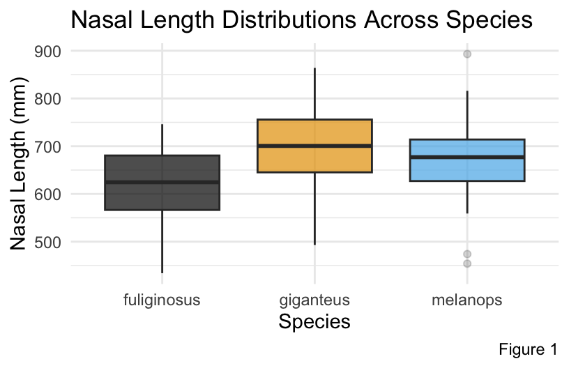

```r
# Plot 1: Predictors used (1): nasal.length
ggplot(kangaroos, aes(x = species, y = nasal.length, fill = species)) +
  geom_boxplot(alpha = 0.7, outlier.alpha = 0.2) +
  labs(
    title = "Nasal Length Distributions Across Species",
    x = "Species",
    y = "Nasal Length (mm)",
    caption = "Figure 1"
  ) +
  theme_minimal() +
  theme(legend.position = "none")
```

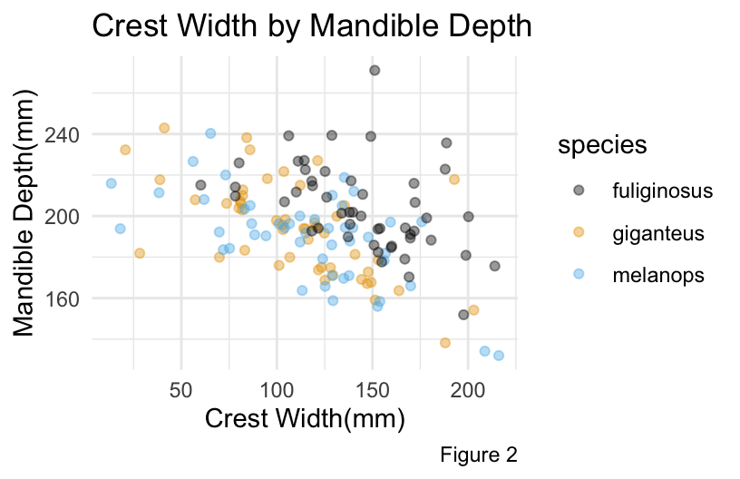

```r
# Plot 2: Predictors used (2): crest.width & mandible.depth
ggplot(kangaroos, aes(x = crest.width, y = mandible.depth, color = species)) +
  geom_point(alpha = 0.4, position = "jitter") +
  labs(
    title = "Crest Width by Mandible Depth",
    x = "Crest Width(mm)",
    y = "Mandible Depth(mm)",
    caption = "Figure 2"
  ) +
  theme_minimal()
```

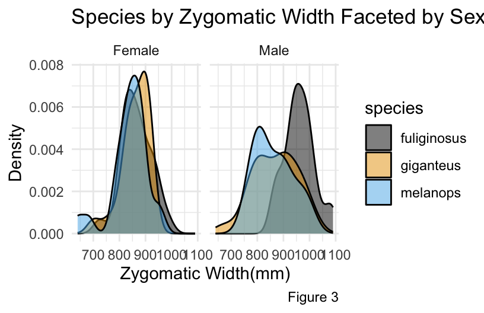

```r
# Plot 3: Predictors used (2): zygomatic.width & sex
  ggplot(kangaroos, aes(x = zygomatic.width, fill = species)) +
  geom_density(alpha = 0.5) +
  facet_wrap("sex") +
  labs(
    title = "Species by Zygomatic Width Faceted by Sex",
    x = "Zygomatic Width(mm)",
    y = "Density",
    caption = "Figure 3"
  ) +
  theme_minimal()
```

A single deep classification tree would depend heavily on which of several nearly interchangeable measurements it happened to split on, which makes it unstable and prone to overfitting. Hence, We used a random forest instead. Averaging many decorrelated trees reduces that variance, and the forest still lets us rank which measurements matter most.

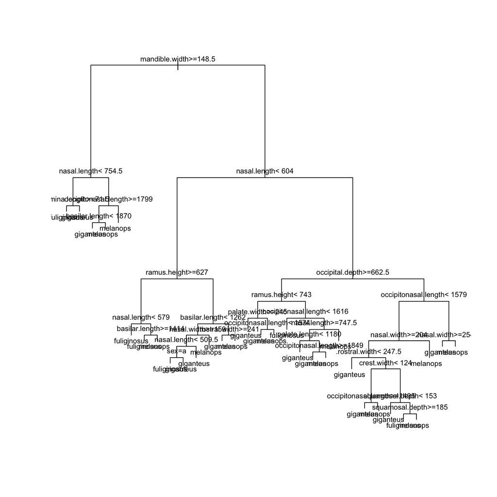

Figure 4

```r
# STEP 1: tree specification with specific tuning parameter values

tree_spec <- decision_tree() |>
  set_mode("classification") |>
  set_engine(engine = "rpart") |>
  set_args(cost_complexity = 0, min_n = 2, tree_depth = 30)

# STEP 2: Build the tree!
# Note that we specified our tuning parameters in Step 1.
# Thus no tuning (hence no workflows) necessary.
kangaroo_tree <- tree_spec |>
  fit(species ~ ., data = kangaroos)

# Plot the tree
kangaroo_tree |>
  extract_fit_engine() |>
  plot(margin = 0)
kangaroo_tree |>
  extract_fit_engine() |>
  text(cex = 0.7)
```

Species was treated as a categorical response, with all 19 other variables as predictors. Of the 148 skulls, 47 were missing at least one measurement and were dropped, leaving 101 complete cases. We grew 500 classification trees, each on a bootstrap sample of those 101 skulls. At each split, 4 of the 19 predictors were randomly chosen as candidates, and the split minimising Gini impurity was chosen. Trees were grown deep, with a minimum node size of 2, and each skull’s class is the majority vote across trees. These were default settings and were not tuned. We set the random seed to 253.

```r
# There's randomness behind the splits!

set.seed(253)

# STEP 1: Model Specification
rf_spec <- rand_forest()  |>
  set_mode("classification") |>
  set_engine(engine = "ranger") |>
  set_args(
    mtry = NULL,
    trees = 500,
    min_n = 2,
    probability = FALSE,    # Report classifications, not probability calculations
    importance = "impurity" # Use Gini index to measure variable importance
  )

# STEP 2: Build the forest
# There are no preprocessing steps or tuning, hence no need for a workflow!
kangaroo_forest <- rf_spec |>
  fit(species ~ ., data = kangaroos)

kangaroo_forest
## parsnip model object
##
## Ranger result
##
## Call:
##  ranger::ranger(x = maybe_data_frame(x), y = y, num.trees = 500,      min.node.size = min_rows(~2, x), probability = FALSE, importance = "impurity",      num.threads = 1, verbose = FALSE, seed = sample.int(10^5,          1))
##
## Type:                             Classification
## Number of trees:                  500
## Sample size:                      101
## Number of independent variables:  19
## Mtry:                             4
## Target node size:                 2
## Variable importance mode:         impurity
## Splitrule:                        gini
## OOB prediction error:             24.75 %
```

We estimated performance with out-of-bag (OOB) error: each skull is classified using only the one-third of trees whose bootstrap samples left it out. The OOB error was 24.75%, so we expect about 75.25% of new skulls to be classified correctly. Guessing the most common species would get about 34% right, as indicated by the no-information rate (NIR) calculated from the confusion matrix below.

```r
# The cbind() includes the original candy data
# alongside their predicted popularity levels
kangaroo_forest |>
  predict(new_data = kangaroos) |>
  cbind(kangaroos) |>
  conf_mat(
    truth = species,
    estimate = .pred_class
  )
##              Truth
## Prediction    fuliginosus giganteus melanops
##   fuliginosus          49         1        2
##   giganteus             1        42       11
##   melanops              0         7       35
```

```r
#Overall accuracy
(49+42+35)/148
## [1] 0.8513514
```

The confusion matrix shows a clear pattern in the errors. Fuliginosus is almost always identified correctly (49 of 50). Nearly all misclassifications are between giganteus and melanops: 11 melanops skulls were labelled giganteus, and 7 giganteus skulls were labelled melanops. Even when predicting its own training data, the forest cannot fully separate these two species, which points to real overlap in their skull measurements.

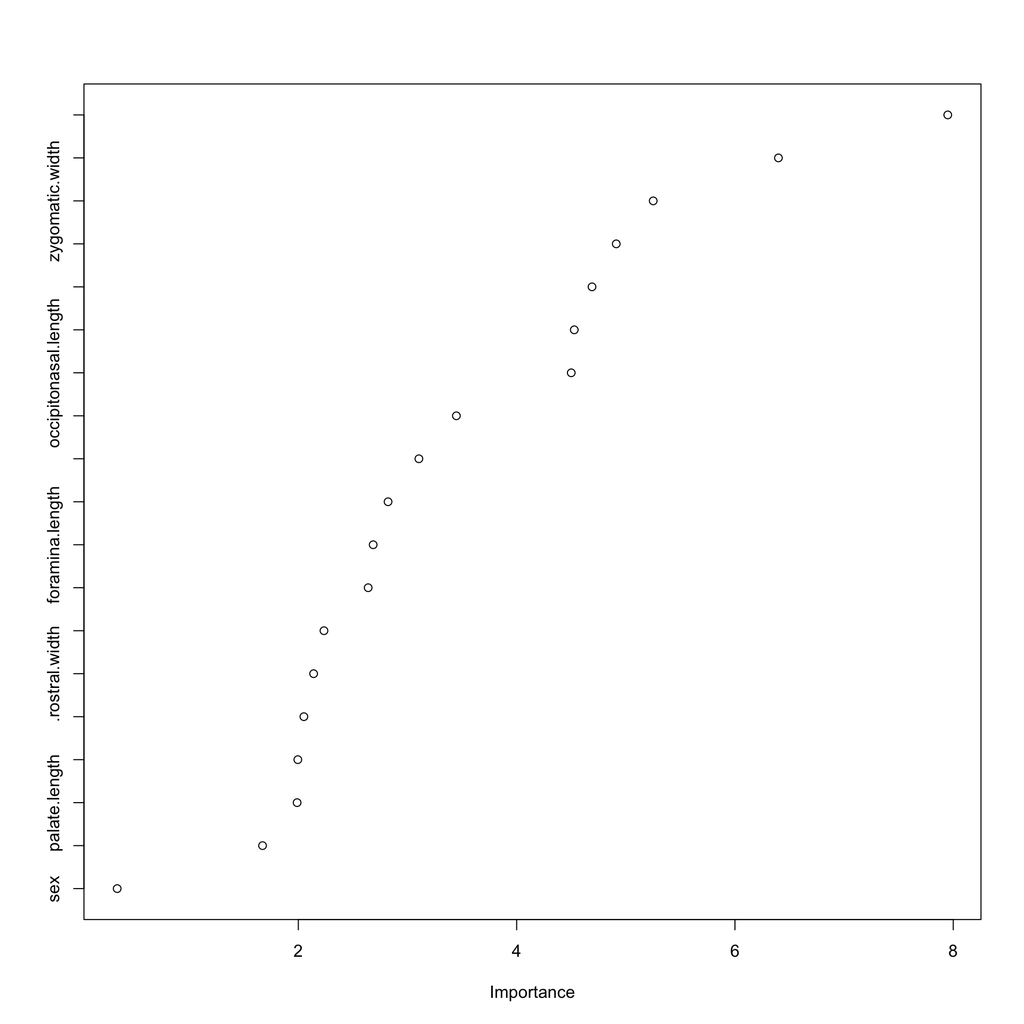

Figure 5

```r
# Print the metrics
kangaroo_forest |>
  extract_fit_engine() |>
  pluck("variable.importance") |>
  sort(decreasing = TRUE)
##         nasal.length          crest.width      zygomatic.width
##            7.9496156            6.3981496            5.2511252
##       mandible.width          nasal.width         ramus.height
##            4.9125923            4.6906111            4.5279696
## occipitonasal.length       mandible.depth      squamosal.depth
##            4.5001858            3.4479052            3.1043659
##      occipital.depth      foramina.length         palate.width
##            2.8220113            2.6855950            2.6398131
##       basilar.length       .rostral.width        orbital.width
##            2.2347720            2.1400072            2.0507011
##      mandible.length        palate.length       lacrymal.width
##            1.9953571            1.9887030            1.6721102
##                  sex
##            0.3404297

# Plot the metrics
library(vip)
kangaroo_forest |>
  vip(geom = "point", num_features = 20)
```

Variable importance, measured by the total decrease in Gini impurity, ranks nasal length, crest width, and zygomatic width highest, followed by mandible width and nasal width. Sex contributes almost nothing. Figures 1–3 show how these top predictors are distributed across species.

# 3. Contributions

Wethu: Early data exploration and the final working code for the prediction model. He worked through the model selection process.

Thusa: Early data exploration (exploratory plots), code debugging and assistance with the analysis, write-up and final revisions.

Shona: Early model exploration and identification of important predictors, worked on revisions and the write up, particularly key takeaways.

# 4. AI Disclosures

We primarily used our in class notes as reference points and prof. Alicia’s advice to complete this project and not AI.